# Predicting Potential Possibilty of Commit Suicide

##### 202055140 이명현 202055152 채원우

## 1. Introduction

```python
# 수치 계산에 사용하는 라이브러리
import numpy as np
import pandas as pd
import scipy as sp
from scipy import stats

# 그래프를 그리기 위한 라이브러리
from matplotlib import pyplot as plt
import seaborn as sns
sns.set()

# 선형모델을 추정하는 라이브러리 (경고가 나올 수 있음)
import statsmodels.formula.api as smf
import statsmodels.api as sm

# 표시 자릿수 지정
%precision %.3f
# 그래프를 주피터 노트북에 그리기 위한 설정
%matplotlib inline
```

```python
data = pd.read_excel("df_1.xlsx")
data
```

|  | Unnamed: 0 | sex | age | age_month | edu | occp | wt_hs | wt_itvex | wt_oe | wt_pft | ... | LF_S10 | LF_S11 | LF_S12 | LF_S13 | LF_S14 | LF_S14_1 | LF_S15 | LF_S16 | LF_SECUR | LF_SECUR_G |
| --- | --- | --- | --- | --- | --- | --- | --- | --- | --- | --- | --- | --- | --- | --- | --- | --- | --- | --- | --- | --- | --- |
| 0 | 0 | M | 61 | NaN | 2.0 | 7.0 | 3605.805922 | 4701.714124 | 5163.891976 | 8642.254524 | ... | NaN | NaN | NaN | NaN | NaN | NaN | NaN | NaN | NaN | NaN |
| 1 | 1 | M | 28 | NaN | 4.0 | 7.0 | 3605.805922 | 8827.818772 | 11745.150419 | NaN | ... | NaN | NaN | NaN | NaN | NaN | NaN | NaN | NaN | NaN | NaN |
| 2 | 2 | M | 53 | NaN | 3.0 | 7.0 | 3605.805922 | 5511.539481 | 7415.114768 | 14178.062845 | ... | 3.0 | 3.0 | 3.0 | 8.0 | 8.0 | 8.0 | 8.0 | 8.0 | 0.0 | 1.0 |
| 3 | 3 | F | 50 | NaN | 3.0 | 1.0 | 3605.805922 | 2992.038760 | 3887.289636 | NaN | ... | 3.0 | 3.0 | 3.0 | 8.0 | 8.0 | 8.0 | 8.0 | 8.0 | 0.0 | 1.0 |
| 4 | 4 | M | 16 | NaN | NaN | NaN | 3605.805922 | NaN | NaN | NaN | ... | 3.0 | 3.0 | 3.0 | 8.0 | 8.0 | 8.0 | 8.0 | 8.0 | 0.0 | 1.0 |
| ... | ... | ... | ... | ... | ... | ... | ... | ... | ... | ... | ... | ... | ... | ... | ... | ... | ... | ... | ... | ... | ... |
| 8105 | 8105 | F | 48 | NaN | 4.0 | 5.0 | 2108.558781 | 3132.931800 | 2140.371347 | 2195.478576 | ... | 3.0 | 3.0 | 3.0 | 8.0 | 8.0 | 8.0 | 8.0 | 8.0 | 0.0 | 1.0 |
| 8106 | 8106 | M | 47 | NaN | 4.0 | 1.0 | 2108.558781 | 6708.290859 | 3475.905947 | 7286.241457 | ... | 3.0 | 3.0 | 3.0 | 8.0 | 8.0 | 8.0 | 8.0 | 8.0 | 0.0 | 1.0 |
| 8107 | 8107 | F | 43 | NaN | 4.0 | 7.0 | 2108.558781 | 3611.951146 | 2145.016064 | NaN | ... | 3.0 | 3.0 | 3.0 | 8.0 | 8.0 | 8.0 | 8.0 | 8.0 | 0.0 | 1.0 |
| 8108 | 8108 | F | 16 | NaN | 2.0 | 7.0 | 2108.558781 | 4130.849257 | 2930.186864 | NaN | ... | 3.0 | 3.0 | 3.0 | 8.0 | 8.0 | 8.0 | 8.0 | 8.0 | 0.0 | 1.0 |
| 8109 | 8109 | M | 8 | NaN | 1.0 | NaN | 2108.558781 | 2092.485069 | 1875.964374 | NaN | ... | 3.0 | 3.0 | 3.0 | 8.0 | 8.0 | 8.0 | 8.0 | 8.0 | 0.0 | 1.0 |

8110 rows × 663 columns

수많은 data 중 사용한 데이터는 다음과 같습니다

ⓐ sex 성별(M 남자, F 여자)  
ⓑ age 만나이  
ⓒ ainc 월평균가계총소득  
ⓓ marri_1 결혼여부(1 yes, 0 no)  
ⓔ LF_SAFE 식생활형편(0 ~ 100)  
ⓕ EQ5D 삶의질 지표(0 ~ 100)  
ⓖ house 주택소지여부(1 yes, 0 no)  
ⓗ LQ_2HT 통증인지정도(1,2,3,4)  
ⓘ LQ_5HT 우울인지정도(1,2,3,4)  
ⓙ LQ_8HT 행복인지정도(1,2,3,4)

ⓚ DF2_dg 의사 우울증 진단 여부(1 yes, 0 no)  
ⓛ BP6_10 1년간 자살 생각 여부(1 yes, 0 no)  
ⓜ BP6_2 1년간 자살 계획 여부(1 yes, 0 no)  
ⓝ BP6_31 1년간 자살 시도 여부(1 yes, 0 no)  
ⓞ BP1 평소 스트레스 인지 정도(0 ~ 100)  
ⓟ BP5 2주 이상 연속 우울감 여부 (1 yes, 0 no)  
ⓠ BP7 1년간 정신문제 상담(1 yes, 0 no)  
ⓡ new, new1 가중치가 부여된 자살위험률

```python
data5 = data[["age", "sex", "HE_ht", "HE_wt",
              "ainc", "marri_1", "LF_SAFE", "EQ5D",
              "house", "LQ_5HT", "LQ_8HT", "LQ_2HT"]]
data2_1 = data5[["age", "sex"]]
data2_2 = data5[["HE_ht", "HE_wt", "ainc"]].fillna(data5[["HE_ht", "HE_wt", "ainc"]].mean())
data2_3 = data5[["marri_1", "LF_SAFE"]]
data2_4 = data5[["EQ5D"]].fillna(data5[["EQ5D"]].mean()).apply(lambda x : x*100)
data2_5 = data5[["house", "LQ_2HT", "LQ_5HT", "LQ_8HT"]]

data2 = pd.concat([data2_1, data2_2, data2_3, data2_4, data2_5], axis = 1)
data2
```

|  | age | sex | HE_ht | HE_wt | ainc | marri_1 | LF_SAFE | EQ5D | house | LQ_2HT | LQ_5HT | LQ_8HT |
| --- | --- | --- | --- | --- | --- | --- | --- | --- | --- | --- | --- | --- |
| 0 | 61 | M | 177.200000 | 81.600000 | 241.666667 | 1 | 50 | 100.000000 | 0 | 50 | 50 | 75 |
| 1 | 28 | M | 174.900000 | 51.700000 | 241.666667 | 0 | 50 | 100.000000 | 0 | 25 | 50 | 50 |
| 2 | 53 | M | 178.600000 | 63.100000 | 150.000000 | 1 | 50 | 100.000000 | 1 | 25 | 25 | 50 |
| 3 | 50 | F | 154.900000 | 63.900000 | 150.000000 | 1 | 50 | 100.000000 | 1 | 25 | 50 | 75 |
| 4 | 16 | M | 158.633133 | 59.448746 | 150.000000 | 0 | 50 | 94.490504 | 1 | 25 | 25 | 75 |
| ... | ... | ... | ... | ... | ... | ... | ... | ... | ... | ... | ... | ... |
| 8105 | 48 | F | 155.100000 | 49.400000 | 545.000000 | 1 | 25 | 100.000000 | 1 | 50 | 50 | 50 |
| 8106 | 47 | M | 166.500000 | 62.100000 | 250.000000 | 1 | 25 | 100.000000 | 0 | 50 | 50 | 50 |
| 8107 | 43 | F | 162.500000 | 40.600000 | 250.000000 | 1 | 25 | 85.400000 | 0 | 25 | 25 | 50 |
| 8108 | 16 | F | 162.500000 | 39.200000 | 250.000000 | 0 | 25 | 94.490504 | 0 | 25 | 25 | 75 |
| 8109 | 8 | M | 125.000000 | 22.700000 | 250.000000 | 0 | 25 | 94.490504 | 0 | 25 | 25 | 75 |

8110 rows × 12 columns

```python
data4 = data[["DF2_dg", "BP6_10", "BP6_2", "BP6_31", "BP7", "BP1", "BP5"]]
data3 = data4.fillna(0)
data3
```

|  | DF2_dg | BP6_10 | BP6_2 | BP6_31 | BP7 | BP1 | BP5 |
| --- | --- | --- | --- | --- | --- | --- | --- |
| 0 | 0.0 | 1.0 | 0.0 | 0.0 | 0.0 | 50.0 | 1.0 |
| 1 | 1.0 | 0.0 | 0.0 | 0.0 | 1.0 | 50.0 | 0.0 |
| 2 | 0.0 | 0.0 | 0.0 | 0.0 | 0.0 | 50.0 | 0.0 |
| 3 | 1.0 | 0.0 | 0.0 | 0.0 | 0.0 | 50.0 | 0.0 |
| 4 | 0.0 | 0.0 | 0.0 | 0.0 | 0.0 | 0.0 | 0.0 |
| ... | ... | ... | ... | ... | ... | ... | ... |
| 8105 | 0.0 | 0.0 | 0.0 | 0.0 | 0.0 | 25.0 | 0.0 |
| 8106 | 0.0 | 0.0 | 0.0 | 0.0 | 0.0 | 50.0 | 0.0 |
| 8107 | 0.0 | 0.0 | 0.0 | 0.0 | 0.0 | 50.0 | 0.0 |
| 8108 | 0.0 | 0.0 | 0.0 | 0.0 | 0.0 | 100.0 | 1.0 |
| 8109 | 0.0 | 0.0 | 0.0 | 0.0 | 0.0 | 0.0 | 0.0 |

8110 rows × 7 columns

▶new 에 해당하는 것은 처음에 우리가 생각한 가중치에 맞추어 계산된 자살위험률

```python
data3["new"] = data3["BP6_10"]*0.1+data3["BP6_2"]*0.1+data3["BP6_31"]*0.3+data3["DF2_dg"]*0.1+data3["BP7"]*0.1+data3["BP5"]*0.15+data3["BP1"]*0.15
```

▶new1 에 해당하는 것은 new 해당하는 선형회귀모델을 만든후 p값에 따라 가중치를 수정한 자살위험률

```python
data3["new1"] = data3["BP6_10"]*0.175 + data3["BP6_2"]*0.1 + data3["BP6_31"]*0.05 + data3["DF2_dg"]*0.175 + data3["BP7"]*0.1 + data3["BP5"]*0.1 + data3["BP1"]*0.4
```

```python
data_f = pd.concat([data2, data3], axis = 1)
data_f
```

|  | age | sex | HE_ht | HE_wt | ainc | marri_1 | LF_SAFE | EQ5D | house | LQ_2HT | ... | LQ_8HT | DF2_dg | BP6_10 | BP6_2 | BP6_31 | BP7 | BP1 | BP5 | new | new1 |
| --- | --- | --- | --- | --- | --- | --- | --- | --- | --- | --- | --- | --- | --- | --- | --- | --- | --- | --- | --- | --- | --- |
| 0 | 61 | M | 177.200000 | 81.600000 | 241.666667 | 1 | 50 | 100.000000 | 0 | 50 | ... | 75 | 0.0 | 1.0 | 0.0 | 0.0 | 0.0 | 50.0 | 1.0 | 7.75 | 20.275 |
| 1 | 28 | M | 174.900000 | 51.700000 | 241.666667 | 0 | 50 | 100.000000 | 0 | 25 | ... | 50 | 1.0 | 0.0 | 0.0 | 0.0 | 1.0 | 50.0 | 0.0 | 7.70 | 20.275 |
| 2 | 53 | M | 178.600000 | 63.100000 | 150.000000 | 1 | 50 | 100.000000 | 1 | 25 | ... | 50 | 0.0 | 0.0 | 0.0 | 0.0 | 0.0 | 50.0 | 0.0 | 7.50 | 20.000 |
| 3 | 50 | F | 154.900000 | 63.900000 | 150.000000 | 1 | 50 | 100.000000 | 1 | 25 | ... | 75 | 1.0 | 0.0 | 0.0 | 0.0 | 0.0 | 50.0 | 0.0 | 7.60 | 20.175 |
| 4 | 16 | M | 158.633133 | 59.448746 | 150.000000 | 0 | 50 | 94.490504 | 1 | 25 | ... | 75 | 0.0 | 0.0 | 0.0 | 0.0 | 0.0 | 0.0 | 0.0 | 0.00 | 0.000 |
| ... | ... | ... | ... | ... | ... | ... | ... | ... | ... | ... | ... | ... | ... | ... | ... | ... | ... | ... | ... | ... | ... |
| 8105 | 48 | F | 155.100000 | 49.400000 | 545.000000 | 1 | 25 | 100.000000 | 1 | 50 | ... | 50 | 0.0 | 0.0 | 0.0 | 0.0 | 0.0 | 25.0 | 0.0 | 3.75 | 10.000 |
| 8106 | 47 | M | 166.500000 | 62.100000 | 250.000000 | 1 | 25 | 100.000000 | 0 | 50 | ... | 50 | 0.0 | 0.0 | 0.0 | 0.0 | 0.0 | 50.0 | 0.0 | 7.50 | 20.000 |
| 8107 | 43 | F | 162.500000 | 40.600000 | 250.000000 | 1 | 25 | 85.400000 | 0 | 25 | ... | 50 | 0.0 | 0.0 | 0.0 | 0.0 | 0.0 | 50.0 | 0.0 | 7.50 | 20.000 |
| 8108 | 16 | F | 162.500000 | 39.200000 | 250.000000 | 0 | 25 | 94.490504 | 0 | 25 | ... | 75 | 0.0 | 0.0 | 0.0 | 0.0 | 0.0 | 100.0 | 1.0 | 15.15 | 40.100 |
| 8109 | 8 | M | 125.000000 | 22.700000 | 250.000000 | 0 | 25 | 94.490504 | 0 | 25 | ... | 75 | 0.0 | 0.0 | 0.0 | 0.0 | 0.0 | 0.0 | 0.0 | 0.00 | 0.000 |

8110 rows × 21 columns

## 2. Main subject

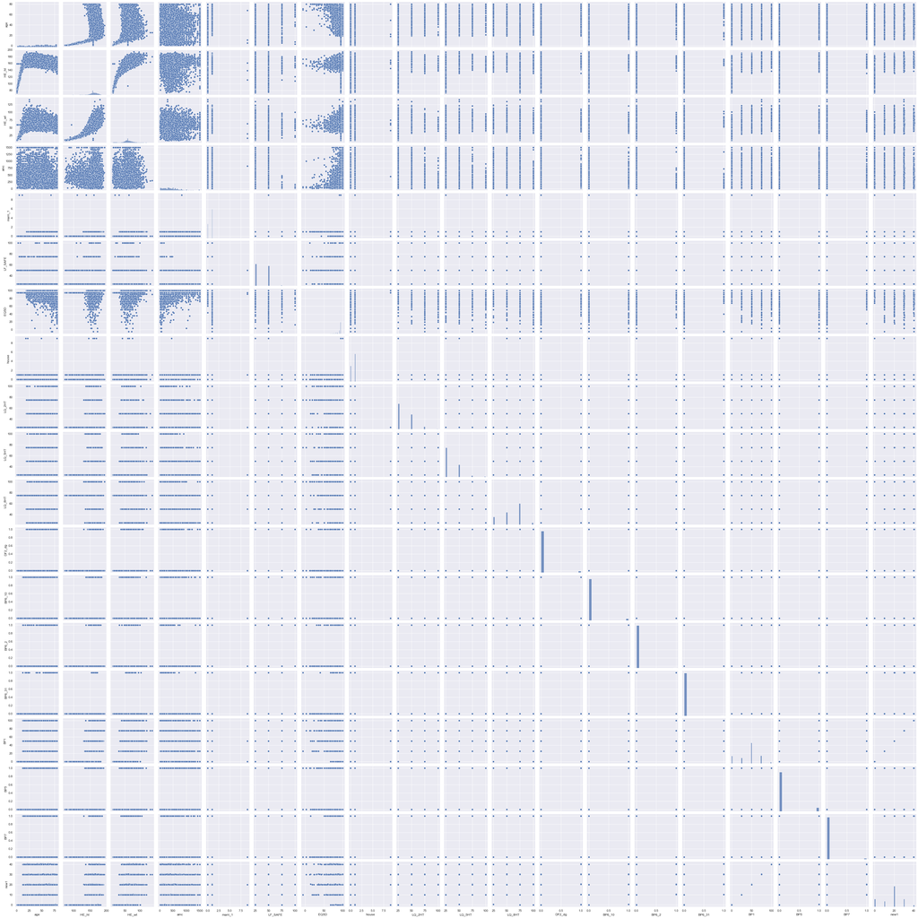

```python
data_f2 = data_f[["age", "HE_ht", "HE_wt", "ainc", "marri_1", "LF_SAFE", "EQ5D", "house",
                  "LQ_2HT", "LQ_5HT", "LQ_8HT", "DF2_dg", "BP6_10", "BP6_2", "BP6_31", "BP1", "BP5", "BP7", "new1"]]
sns.pairplot(data_f2)
```

x 좌표는 순서대로  
age, height, weight, 월소득평균, 결혼여부, 식생활만족도, 삶의질 지표, 주택소지여부, 통증인지정도, 우울인지정도,  
행복인지정도, 우울증 진단, 자살생각여부, 자살계획여부, 자살시도여부  
평소스트레스인지정도, 2주이상 연속우울감여부, 정신문제상담여부, 자살위험률  
입니다.

```python
model1 = smf.glm(formula = "DF2_dg ~ ainc + marri_1 + LF_SAFE + HE_ht + HE_wt + EQ5D + age + sex + house + LQ_5HT + LQ_8HT + LQ_2HT ", data = data_f, family = sm.families.Binomial()).fit()
model2 = smf.glm(formula = "BP6_10 ~ ainc + marri_1 + LF_SAFE + HE_ht + HE_wt + EQ5D + age + sex + house + LQ_5HT + LQ_8HT + LQ_2HT ", data = data_f, family = sm.families.Binomial()).fit()
model3 = smf.glm(formula = "BP6_2~ ainc + marri_1 + LF_SAFE + HE_ht + HE_wt + EQ5D + age + sex + house + LQ_5HT + LQ_8HT + LQ_2HT ", data = data_f, family = sm.families.Binomial()).fit()
model4 = smf.glm(formula = "BP6_31 ~ ainc + marri_1 + LF_SAFE + HE_ht + HE_wt + EQ5D + age + sex + house + LQ_5HT + LQ_8HT + LQ_2HT ", data = data_f, family = sm.families.Binomial()).fit()
model5 = smf.glm(formula = "BP7 ~ ainc + marri_1 + LF_SAFE + HE_ht + HE_wt + EQ5D + age + sex + house + LQ_5HT + LQ_8HT + LQ_2HT ", data = data_f, family = sm.families.Binomial()).fit()
model6 = smf.ols(formula = "BP1 ~ ainc + marri_1 + LF_SAFE + HE_ht + HE_wt + EQ5D + age + sex + house + LQ_5HT + LQ_8HT + LQ_2HT ", data = data_f).fit()
model7 = smf.glm(formula = "BP5 ~ ainc + marri_1 + LF_SAFE + HE_ht + HE_wt + EQ5D + age + sex + house + LQ_5HT + LQ_8HT + LQ_2HT ", data = data_f, family = sm.families.Binomial()).fit()
```

```python
model1.summary()
```

Generalized Linear Model Regression Results

| Dep. Variable: | DF2_dg | No. Observations: | 8110 |
| --- | --- | --- | --- |
| Model: | GLM | Df Residuals: | 8097 |
| Model Family: | Binomial | Df Model: | 12 |
| Link Function: | logit | Scale: | 1.0000 |
| Method: | IRLS | Log-Likelihood: | -1062.7 |
| Date: | Tue, 08 Jun 2021 | Deviance: | 2125.4 |
| Time: | 16:11:48 | Pearson chi2: | 6.49e+03 |
| No. Iterations: | 8 |  |  |
| Covariance Type: | nonrobust |  |  |

|  | coef | std err | z | P>\|z\| | [0.025 | 0.975] |
| --- | --- | --- | --- | --- | --- | --- |
| Intercept | -7.8773 | 1.706 | -4.618 | 0.000 | -11.221 | -4.534 |
| sex[T.M] | -0.9621 | 0.185 | -5.209 | 0.000 | -1.324 | -0.600 |
| ainc | -0.0007 | 0.000 | -2.605 | 0.009 | -0.001 | -0.000 |
| marri_1 | 0.0234 | 0.217 | 0.108 | 0.914 | -0.401 | 0.448 |
| LF_SAFE | -0.0034 | 0.004 | -0.782 | 0.434 | -0.012 | 0.005 |
| HE_ht | 0.0158 | 0.010 | 1.527 | 0.127 | -0.004 | 0.036 |
| HE_wt | 0.0194 | 0.006 | 3.193 | 0.001 | 0.007 | 0.031 |
| EQ5D | -0.0088 | 0.005 | -1.710 | 0.087 | -0.019 | 0.001 |
| age | 0.0166 | 0.005 | 3.133 | 0.002 | 0.006 | 0.027 |
| house | -0.0843 | 0.133 | -0.633 | 0.527 | -0.345 | 0.177 |
| LQ_5HT | 0.0420 | 0.004 | 11.580 | 0.000 | 0.035 | 0.049 |
| LQ_8HT | -0.0037 | 0.003 | -1.115 | 0.265 | -0.010 | 0.003 |
| LQ_2HT | 0.0015 | 0.004 | 0.387 | 0.699 | -0.006 | 0.009 |

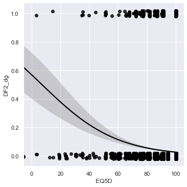

```python
sns.lmplot(x = "EQ5D", y = "DF2_dg", data = data_f, logistic = True, scatter_kws = {"color": "black"},
           line_kws    = {"color": "black"},
           x_jitter = 0.2, y_jitter = 0.02)
```

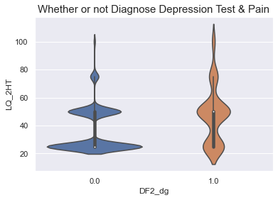

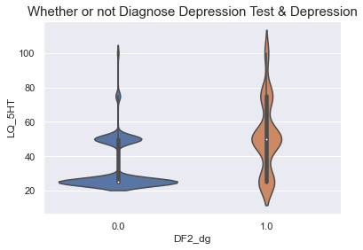

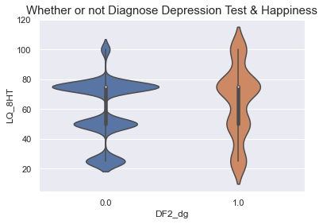

```python
plt.figure(1)
sns.violinplot(x = "DF2_dg", y = "LQ_2HT", data = data_f)
plt.title("Whether or not Diagnose Depression Test & Pain", fontsize = 15)
plt.figure(2)
sns.violinplot(x = "DF2_dg", y = "LQ_5HT", data = data_f)
plt.title("Whether or not Diagnose Depression Test & Depression", fontsize = 15)
plt.figure(3)
sns.violinplot(x = "DF2_dg", y = "LQ_8HT", data = data_f)
plt.title("Whether or not Diagnose Depression Test & Happiness", fontsize = 15)
```

```python
model2.summary()
```

Generalized Linear Model Regression Results

| Dep. Variable: | BP6_10 | No. Observations: | 8110 |
| --- | --- | --- | --- |
| Model: | GLM | Df Residuals: | 8097 |
| Model Family: | Binomial | Df Model: | 12 |
| Link Function: | logit | Scale: | 1.0000 |
| Method: | IRLS | Log-Likelihood: | -1015.8 |
| Date: | Tue, 08 Jun 2021 | Deviance: | 2031.6 |
| Time: | 16:12:37 | Pearson chi2: | 6.75e+03 |
| No. Iterations: | 8 |  |  |
| Covariance Type: | nonrobust |  |  |

|  | coef | std err | z | P>\|z\| | [0.025 | 0.975] |
| --- | --- | --- | --- | --- | --- | --- |
| Intercept | -9.8159 | 1.460 | -6.722 | 0.000 | -12.678 | -6.954 |
| sex[T.M] | -0.2693 | 0.163 | -1.648 | 0.099 | -0.590 | 0.051 |
| ainc | -0.0013 | 0.000 | -4.477 | 0.000 | -0.002 | -0.001 |
| marri_1 | 0.0540 | 0.210 | 0.257 | 0.797 | -0.358 | 0.466 |
| LF_SAFE | 0.0028 | 0.004 | 0.664 | 0.507 | -0.005 | 0.011 |
| HE_ht | 0.0265 | 0.009 | 2.888 | 0.004 | 0.009 | 0.044 |
| HE_wt | 0.0052 | 0.006 | 0.849 | 0.396 | -0.007 | 0.017 |
| EQ5D | -0.0163 | 0.005 | -3.276 | 0.001 | -0.026 | -0.007 |
| age | -0.0002 | 0.005 | -0.037 | 0.970 | -0.010 | 0.010 |
| house | -0.0818 | 0.132 | -0.618 | 0.536 | -0.341 | 0.177 |
| LQ_5HT | 0.0450 | 0.003 | 12.898 | 0.000 | 0.038 | 0.052 |
| LQ_8HT | 0.0272 | 0.004 | 7.033 | 0.000 | 0.020 | 0.035 |
| LQ_2HT | 0.0066 | 0.004 | 1.641 | 0.101 | -0.001 | 0.014 |

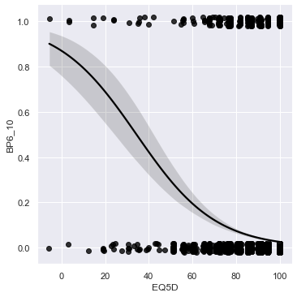

```python
sns.lmplot(x = "EQ5D", y = "BP6_10", data = data_f, logistic = True, scatter_kws = {"color": "black"},
           line_kws    = {"color": "black"},
           x_jitter = 0.2, y_jitter = 0.02)
```

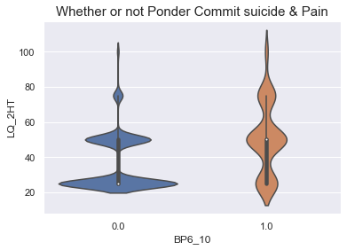

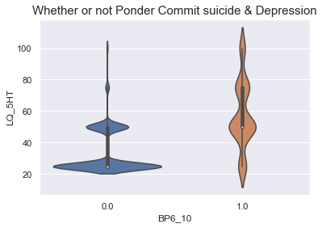

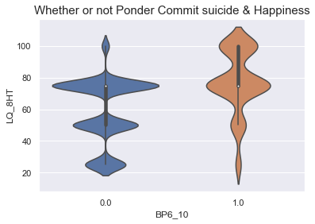

```python
plt.figure(1)
sns.violinplot(x = "BP6_10", y = "LQ_2HT", data = data_f)
plt.title("Whether or not Ponder Commit suicide & Pain", fontsize = 15)
plt.figure(2)
sns.violinplot(x = "BP6_10", y = "LQ_5HT", data = data_f)
plt.title("Whether or not Ponder Commit suicide & Depression", fontsize = 15)
plt.figure(3)
sns.violinplot(x = "BP6_10", y = "LQ_8HT", data = data_f)
plt.title("Whether or not Ponder Commit suicide & Happiness", fontsize = 15)
```

```python
model3.summary()
```

Generalized Linear Model Regression Results

| Dep. Variable: | BP6_2 | No. Observations: | 8110 |
| --- | --- | --- | --- |
| Model: | GLM | Df Residuals: | 8097 |
| Model Family: | Binomial | Df Model: | 12 |
| Link Function: | logit | Scale: | 1.0000 |
| Method: | IRLS | Log-Likelihood: | -361.94 |
| Date: | Tue, 08 Jun 2021 | Deviance: | 723.89 |
| Time: | 16:13:23 | Pearson chi2: | 7.49e+03 |
| No. Iterations: | 9 |  |  |
| Covariance Type: | nonrobust |  |  |

|  | coef | std err | z | P>\|z\| | [0.025 | 0.975] |
| --- | --- | --- | --- | --- | --- | --- |
| Intercept | -12.1732 | 2.858 | -4.259 | 0.000 | -17.775 | -6.571 |
| sex[T.M] | 0.0627 | 0.306 | 0.205 | 0.838 | -0.537 | 0.662 |
| ainc | -0.0015 | 0.001 | -2.520 | 0.012 | -0.003 | -0.000 |
| marri_1 | 0.2480 | 0.364 | 0.681 | 0.496 | -0.466 | 0.962 |
| LF_SAFE | 0.0107 | 0.007 | 1.543 | 0.123 | -0.003 | 0.024 |
| HE_ht | 0.0203 | 0.018 | 1.146 | 0.252 | -0.014 | 0.055 |
| HE_wt | 0.0175 | 0.010 | 1.687 | 0.092 | -0.003 | 0.038 |
| EQ5D | -0.0079 | 0.007 | -1.066 | 0.287 | -0.022 | 0.007 |
| age | -0.0011 | 0.010 | -0.113 | 0.910 | -0.020 | 0.018 |
| house | -0.2156 | 0.245 | -0.880 | 0.379 | -0.696 | 0.264 |
| LQ_5HT | 0.0405 | 0.006 | 6.997 | 0.000 | 0.029 | 0.052 |
| LQ_8HT | 0.0247 | 0.007 | 3.382 | 0.001 | 0.010 | 0.039 |
| LQ_2HT | 0.0109 | 0.007 | 1.631 | 0.103 | -0.002 | 0.024 |

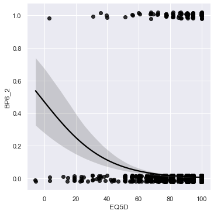

```python
sns.lmplot(x = "EQ5D", y = "BP6_2", data = data_f, logistic = True, scatter_kws = {"color": "black"},
           line_kws    = {"color": "black"},
           x_jitter = 0.2, y_jitter = 0.02)
```

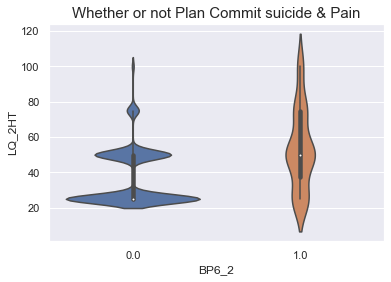

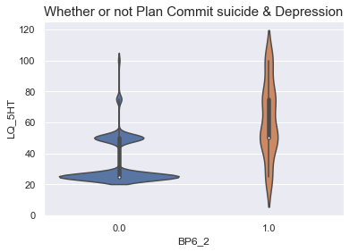

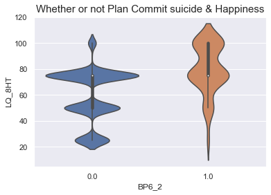

```python
plt.figure(1)
sns.violinplot(x = "BP6_2", y = "LQ_2HT", data = data_f)
plt.title("Whether or not Plan Commit suicide & Pain", fontsize = 15)
plt.figure(2)
sns.violinplot(x = "BP6_2", y = "LQ_5HT", data = data_f)
plt.title("Whether or not Plan Commit suicide & Depression", fontsize = 15)
plt.figure(3)
sns.violinplot(x = "BP6_2", y = "LQ_8HT", data = data_f)
plt.title("Whether or not Plan Commit suicide & Happiness", fontsize = 15)
```

```python
model4.summary()
```

Generalized Linear Model Regression Results

| Dep. Variable: | BP6_31 | No. Observations: | 8110 |
| --- | --- | --- | --- |
| Model: | GLM | Df Residuals: | 8097 |
| Model Family: | Binomial | Df Model: | 12 |
| Link Function: | logit | Scale: | 1.0000 |
| Method: | IRLS | Log-Likelihood: | -153.72 |
| Date: | Tue, 08 Jun 2021 | Deviance: | 307.44 |
| Time: | 16:14:21 | Pearson chi2: | 7.99e+03 |
| No. Iterations: | 10 |  |  |
| Covariance Type: | nonrobust |  |  |

|  | coef | std err | z | P>\|z\| | [0.025 | 0.975] |
| --- | --- | --- | --- | --- | --- | --- |
| Intercept | -6.6124 | 3.930 | -1.683 | 0.092 | -14.315 | 1.090 |
| sex[T.M] | -0.8431 | 0.498 | -1.693 | 0.090 | -1.819 | 0.133 |
| ainc | -0.0007 | 0.001 | -0.855 | 0.392 | -0.002 | 0.001 |
| marri_1 | -1.0138 | 0.624 | -1.625 | 0.104 | -2.236 | 0.209 |
| LF_SAFE | 0.0044 | 0.013 | 0.351 | 0.726 | -0.020 | 0.029 |
| HE_ht | -0.0041 | 0.025 | -0.167 | 0.867 | -0.052 | 0.044 |
| HE_wt | 0.0461 | 0.014 | 3.280 | 0.001 | 0.019 | 0.074 |
| EQ5D | -0.0296 | 0.011 | -2.622 | 0.009 | -0.052 | -0.007 |
| age | -0.0006 | 0.016 | -0.041 | 0.967 | -0.032 | 0.030 |
| house | 0.1465 | 0.360 | 0.407 | 0.684 | -0.560 | 0.853 |
| LQ_5HT | 0.0358 | 0.010 | 3.534 | 0.000 | 0.016 | 0.056 |
| LQ_8HT | 0.0171 | 0.012 | 1.409 | 0.159 | -0.007 | 0.041 |
| LQ_2HT | -0.0083 | 0.012 | -0.679 | 0.497 | -0.032 | 0.016 |

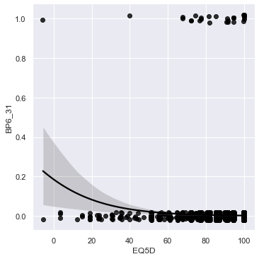

```python
sns.lmplot(x = "EQ5D", y = "BP6_31", data = data_f, logistic = True, scatter_kws = {"color": "black"},
           line_kws    = {"color": "black"},
           x_jitter = 0.2, y_jitter = 0.02)
```

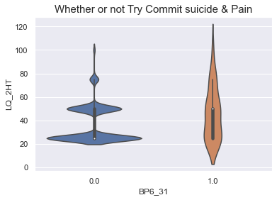

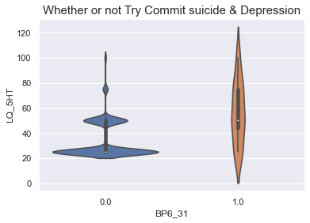

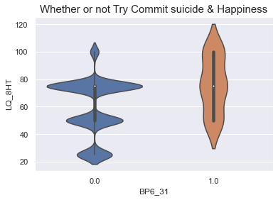

```python
plt.figure(1)
sns.violinplot(x = "BP6_31", y = "LQ_2HT", data = data_f)
plt.title("Whether or not Try Commit suicide & Pain", fontsize = 15)
plt.figure(2)
sns.violinplot(x = "BP6_31", y = "LQ_5HT", data = data_f)
plt.title("Whether or not Try Commit suicide & Depression", fontsize = 15)
plt.figure(3)
sns.violinplot(x = "BP6_31", y = "LQ_8HT", data = data_f)
plt.title("Whether or not Try Commit suicide & Happiness", fontsize = 15)
```

```python
model5.summary()
```

Generalized Linear Model Regression Results

| Dep. Variable: | BP7 | No. Observations: | 8110 |
| --- | --- | --- | --- |
| Model: | GLM | Df Residuals: | 8097 |
| Model Family: | Binomial | Df Model: | 12 |
| Link Function: | logit | Scale: | 1.0000 |
| Method: | IRLS | Log-Likelihood: | -840.73 |
| Date: | Tue, 08 Jun 2021 | Deviance: | 1681.5 |
| Time: | 16:15:30 | Pearson chi2: | 7.20e+03 |
| No. Iterations: | 8 |  |  |
| Covariance Type: | nonrobust |  |  |

|  | coef | std err | z | P>\|z\| | [0.025 | 0.975] |
| --- | --- | --- | --- | --- | --- | --- |
| Intercept | -9.0045 | 1.598 | -5.636 | 0.000 | -12.136 | -5.873 |
| sex[T.M] | -0.5418 | 0.186 | -2.907 | 0.004 | -0.907 | -0.177 |
| ainc | -0.0006 | 0.000 | -2.022 | 0.043 | -0.001 | -1.8e-05 |
| marri_1 | 0.2295 | 0.199 | 1.155 | 0.248 | -0.160 | 0.619 |
| LF_SAFE | -0.0031 | 0.005 | -0.600 | 0.549 | -0.013 | 0.007 |
| HE_ht | 0.0241 | 0.010 | 2.429 | 0.015 | 0.005 | 0.043 |
| HE_wt | 0.0054 | 0.007 | 0.771 | 0.441 | -0.008 | 0.019 |
| EQ5D | -0.0011 | 0.006 | -0.174 | 0.862 | -0.014 | 0.012 |
| age | -0.0123 | 0.006 | -2.220 | 0.026 | -0.023 | -0.001 |
| house | -0.2389 | 0.154 | -1.550 | 0.121 | -0.541 | 0.063 |
| LQ_5HT | 0.0426 | 0.004 | 10.199 | 0.000 | 0.034 | 0.051 |
| LQ_8HT | 0.0056 | 0.004 | 1.325 | 0.185 | -0.003 | 0.014 |
| LQ_2HT | 0.0060 | 0.005 | 1.250 | 0.211 | -0.003 | 0.015 |

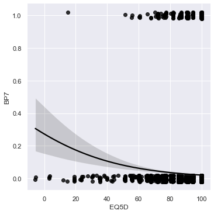

```python
sns.lmplot(x = "EQ5D", y = "BP7", data = data_f, logistic = True, scatter_kws = {"color": "black"},
           line_kws    = {"color": "black"},
           x_jitter = 0.2, y_jitter = 0.02)
```

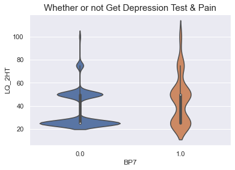

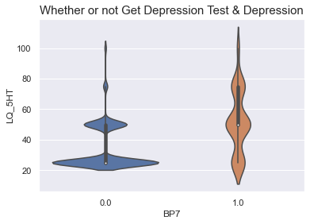

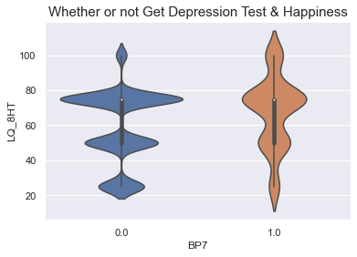

```python
plt.figure(1)
sns.violinplot(x = "BP7", y = "LQ_2HT", data = data_f)
plt.title("Whether or not Get Depression Test & Pain", fontsize = 15)
plt.figure(2)
sns.violinplot(x = "BP7", y = "LQ_5HT", data = data_f)
plt.title("Whether or not Get Depression Test & Depression", fontsize = 15)
plt.figure(3)
sns.violinplot(x = "BP7", y = "LQ_8HT", data = data_f)
plt.title("Whether or not Get Depression Test & Happiness", fontsize = 15)
```

```python
model6.summary()
```

OLS Regression Results

| Dep. Variable: | BP1 | R-squared: | 0.473 |
| --- | --- | --- | --- |
| Model: | OLS | Adj. R-squared: | 0.473 |
| Method: | Least Squares | F-statistic: | 606.7 |
| Date: | Tue, 08 Jun 2021 | Prob (F-statistic): | 0.00 |
| Time: | 16:16:21 | Log-Likelihood: | -35445. |
| No. Observations: | 8110 | AIC: | 7.092e+04 |
| Df Residuals: | 8097 | BIC: | 7.101e+04 |
| Df Model: | 12 |  |  |
| Covariance Type: | nonrobust |  |  |

|  | coef | std err | t | P>\|t\| | [0.025 | 0.975] |
| --- | --- | --- | --- | --- | --- | --- |
| Intercept | -100.0733 | 3.901 | -25.651 | 0.000 | -107.721 | -92.426 |
| sex[T.M] | -6.9480 | 0.471 | -14.759 | 0.000 | -7.871 | -6.025 |
| ainc | 0.0019 | 0.001 | 2.484 | 0.013 | 0.000 | 0.003 |
| marri_1 | 2.1319 | 0.661 | 3.225 | 0.001 | 0.836 | 3.428 |
| LF_SAFE | 0.0460 | 0.016 | 2.884 | 0.004 | 0.015 | 0.077 |
| HE_ht | 0.5509 | 0.022 | 24.855 | 0.000 | 0.507 | 0.594 |
| HE_wt | 0.1898 | 0.022 | 8.491 | 0.000 | 0.146 | 0.234 |
| EQ5D | 0.1937 | 0.027 | 7.079 | 0.000 | 0.140 | 0.247 |
| age | -0.0214 | 0.016 | -1.328 | 0.184 | -0.053 | 0.010 |
| house | -1.0610 | 0.432 | -2.454 | 0.014 | -1.909 | -0.213 |
| LQ_5HT | 0.6003 | 0.017 | 36.068 | 0.000 | 0.568 | 0.633 |
| LQ_8HT | -0.0410 | 0.012 | -3.463 | 0.001 | -0.064 | -0.018 |
| LQ_2HT | 0.2696 | 0.016 | 16.393 | 0.000 | 0.237 | 0.302 |

| Omnibus: | 9.598 | Durbin-Watson: | 1.893 |
| --- | --- | --- | --- |
| Prob(Omnibus): | 0.008 | Jarque-Bera (JB): | 9.995 |
| Skew: | 0.059 | Prob(JB): | 0.00675 |
| Kurtosis: | 3.124 | Cond. No. | 1.07e+04 |

Warnings:  
[1] Standard Errors assume that the covariance matrix of the errors is correctly specified.  
[2] The condition number is large, 1.07e+04. This might indicate that there are  
strong multicollinearity or other numerical problems.

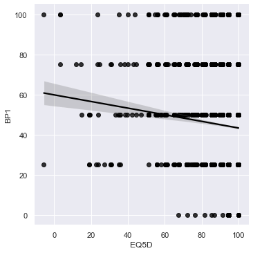

```python
sns.lmplot(x = "EQ5D", y = "BP1", data = data_f, scatter_kws = {"color": "black"},
           line_kws    = {"color": "black"},
           x_jitter = 0.2, y_jitter = 0.02)
```

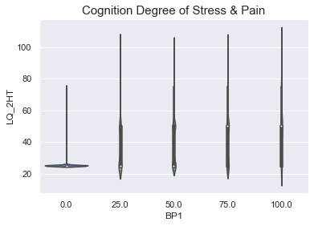

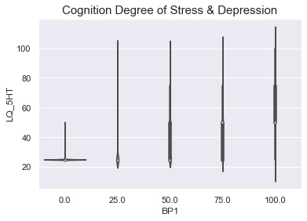

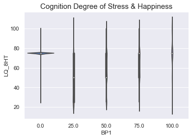

```python
plt.figure(1)
sns.violinplot(x = "BP1", y = "LQ_2HT", data = data_f)
plt.title("Cognition Degree of Stress & Pain", fontsize = 15)
plt.figure(2)
sns.violinplot(x = "BP1", y = "LQ_5HT", data = data_f)
plt.title("Cognition Degree of Stress & Depression", fontsize = 15)
plt.figure(3)
sns.violinplot(x = "BP1", y = "LQ_8HT", data = data_f)
plt.title("Cognition Degree of Stress & Happiness", fontsize = 15)
```

```python
model7.summary()
```

Generalized Linear Model Regression Results

| Dep. Variable: | BP5 | No. Observations: | 8110 |
| --- | --- | --- | --- |
| Model: | GLM | Df Residuals: | 8097 |
| Model Family: | Binomial | Df Model: | 12 |
| Link Function: | logit | Scale: | 1.0000 |
| Method: | IRLS | Log-Likelihood: | -1871.4 |
| Date: | Tue, 08 Jun 2021 | Deviance: | 3742.8 |
| Time: | 16:16:26 | Pearson chi2: | 7.37e+03 |
| No. Iterations: | 7 |  |  |
| Covariance Type: | nonrobust |  |  |

|  | coef | std err | z | P>\|z\| | [0.025 | 0.975] |
| --- | --- | --- | --- | --- | --- | --- |
| Intercept | -10.3121 | 1.060 | -9.733 | 0.000 | -12.389 | -8.235 |
| sex[T.M] | -0.5593 | 0.116 | -4.809 | 0.000 | -0.787 | -0.331 |
| ainc | -0.0003 | 0.000 | -1.846 | 0.065 | -0.001 | 1.87e-05 |
| marri_1 | -0.1403 | 0.147 | -0.952 | 0.341 | -0.429 | 0.149 |
| LF_SAFE | -0.0001 | 0.003 | -0.039 | 0.969 | -0.006 | 0.006 |
| HE_ht | 0.0287 | 0.007 | 4.396 | 0.000 | 0.016 | 0.041 |
| HE_wt | 0.0060 | 0.004 | 1.380 | 0.167 | -0.003 | 0.015 |
| EQ5D | -0.0059 | 0.004 | -1.383 | 0.167 | -0.014 | 0.002 |
| age | 0.0059 | 0.004 | 1.612 | 0.107 | -0.001 | 0.013 |
| house | -0.0450 | 0.092 | -0.491 | 0.623 | -0.224 | 0.134 |
| LQ_5HT | 0.0535 | 0.003 | 18.916 | 0.000 | 0.048 | 0.059 |
| LQ_8HT | 0.0215 | 0.003 | 8.259 | 0.000 | 0.016 | 0.027 |
| LQ_2HT | 0.0037 | 0.003 | 1.225 | 0.221 | -0.002 | 0.010 |

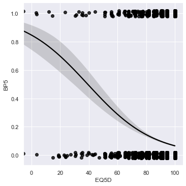

```python
sns.lmplot(x = "EQ5D", y = "BP5", data = data_f, logistic = True, scatter_kws = {"color": "black"},
           line_kws    = {"color": "black"},
           x_jitter = 0.2, y_jitter = 0.02)
```

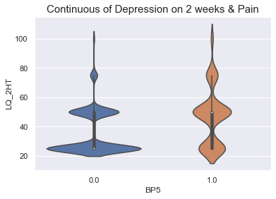

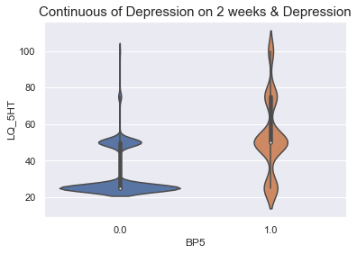

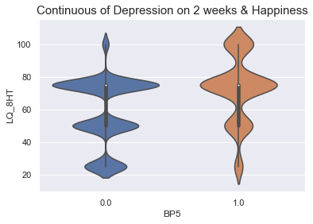

```python
plt.figure(1)
sns.violinplot(x = "BP5", y = "LQ_2HT", data = data_f)
plt.title("Continuous of Depression on 2 weeks & Pain", fontsize = 15)
plt.figure(2)
sns.violinplot(x = "BP5", y = "LQ_5HT", data = data_f)
plt.title("Continuous of Depression on 2 weeks & Depression", fontsize = 15)
plt.figure(3)
sns.violinplot(x = "BP5", y = "LQ_8HT", data = data_f)
plt.title("Continuous of Depression on 2 weeks & Happiness", fontsize = 15)
```

### Final Result

```python
model_fin = smf.ols(formula = "new1 ~ ainc + marri_1 + LF_SAFE + HE_ht + HE_wt + EQ5D + sex + house + LQ_5HT + LQ_8HT + LQ_2HT ", data = data_f).fit()
# 나이의 경우 p값이 0.181이 나오기 때문에 제외합니다.
```

```python
model_fin.summary()
```

OLS Regression Results

| Dep. Variable: | new1 | R-squared: | 0.474 |
| --- | --- | --- | --- |
| Model: | OLS | Adj. R-squared: | 0.474 |
| Method: | Least Squares | F-statistic: | 664.3 |
| Date: | Tue, 08 Jun 2021 | Prob (F-statistic): | 0.00 |
| Time: | 16:17:06 | Log-Likelihood: | -28025. |
| No. Observations: | 8110 | AIC: | 5.607e+04 |
| Df Residuals: | 8098 | BIC: | 5.616e+04 |
| Df Model: | 11 |  |  |
| Covariance Type: | nonrobust |  |  |

|  | coef | std err | t | P>\|t\| | [0.025 | 0.975] |
| --- | --- | --- | --- | --- | --- | --- |
| Intercept | -40.1373 | 1.560 | -25.737 | 0.000 | -43.194 | -37.080 |
| sex[T.M] | -2.7739 | 0.188 | -14.720 | 0.000 | -3.143 | -2.405 |
| ainc | 0.0009 | 0.000 | 2.993 | 0.003 | 0.000 | 0.001 |
| marri_1 | 0.6162 | 0.196 | 3.146 | 0.002 | 0.232 | 1.000 |
| LF_SAFE | 0.0178 | 0.006 | 2.790 | 0.005 | 0.005 | 0.030 |
| HE_ht | 0.2192 | 0.009 | 24.819 | 0.000 | 0.202 | 0.237 |
| HE_wt | 0.0754 | 0.009 | 8.442 | 0.000 | 0.058 | 0.093 |
| EQ5D | 0.0783 | 0.011 | 7.200 | 0.000 | 0.057 | 0.100 |
| house | -0.4671 | 0.171 | -2.739 | 0.006 | -0.801 | -0.133 |
| LQ_5HT | 0.2417 | 0.007 | 36.290 | 0.000 | 0.229 | 0.255 |
| LQ_8HT | -0.0157 | 0.005 | -3.329 | 0.001 | -0.025 | -0.006 |
| LQ_2HT | 0.1067 | 0.007 | 16.352 | 0.000 | 0.094 | 0.119 |

| Omnibus: | 9.953 | Durbin-Watson: | 1.893 |
| --- | --- | --- | --- |
| Prob(Omnibus): | 0.007 | Jarque-Bera (JB): | 10.390 |
| Skew: | 0.060 | Prob(JB): | 0.00555 |
| Kurtosis: | 3.127 | Cond. No. | 1.06e+04 |

Warnings:  
[1] Standard Errors assume that the covariance matrix of the errors is correctly specified.  
[2] The condition number is large, 1.06e+04. This might indicate that there are  
strong multicollinearity or other numerical problems.

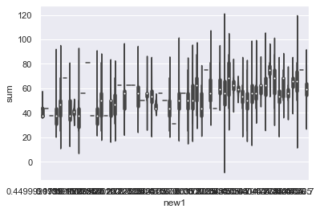

```python
data_calc = data_f[["LF_SAFE", "LQ_2HT", "LQ_5HT", "LQ_8HT", "new1", "new"]]
data_calc["sum"] = (data_calc["LF_SAFE"] + data_calc["LQ_2HT"] + data_calc["LQ_5HT"] + data_calc["LQ_8HT"])/4
sns.violinplot(x = "new1", y = "sum", data = data_calc)
# data_calc
```

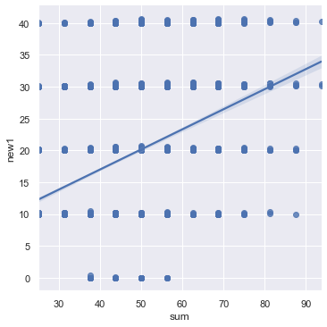

```python
sns.lmplot(x = "sum", y = "new1", data = data_calc)
```

## 3. Conclusion

#### 자신의 정보를 대입하여 자살위험률를 예측하는 것을 만들었습니다.

data3["new1"] = data3["BP6_10"] *0.175 + data3["BP6_2"]* 0.1 + data3["BP6_31"] *0.05 + data3["DF2_dg"]* 0.175 +  
data3["BP7"] *0.1 + data3["BP5"]* 0.1 + data3["BP1"] * 0.4

DF2_dg 의사 우울증 진단 여부(1 yes, 0 no) 17.5%  
BP6_10 1년간 자살 생각 여부(1 yes, 0 no) 17.5%  
BP6_2 1년간 자살 계획 여부(1 yes, 0 no) 10%  
BP6_31 1년간 자살 시도 여부(1 yes, 0 no) 5%  
BP1 평소 스트레스 인지 정도(0 ~ 100) 40%  
BP5 2주 이상 연속 우울감 여부 (1 yes, 0 no) 10%  
BP7 1년간 정신문제 상담(1 yes, 0 no) 10%  
new, new1 가중치가 부여된 자살위험률 100%

```python
def suicide_dangerous_rate():
    name = input("이름을 입력해주세요: ")
    ainc = float(input("월평균가계총소득을 입력해주세요(단위=만원): "))
    marri_1 = float(input("결혼여부를 말해주세요(현재 결혼상태에 있으면1 미혼상태면 0을 입력해주세요): "))
    LF_SAFE = float(input("식생활형편을 말해주세요(0~100까지의 숫자를 입력하되 숫자가 높을수록 빈곤한 상태입니다): "))
    HE_ht = float(input("본인의 키를 알려주세요: "))
    HE_wt = float(input("본인의 몸무게를 입력해주세요: "))
    EQ5D = float(input("삶의 질 지표를 알려주세요(0~100까지의 숫자를 입력하되 숫자가 높을수록 삶의 질이 좋은 상태입니다): "))
    age = int(input("본인의 나이를 말해주세요: "))
    sex = input("본인의 성별을 말해주세요(남자는 M을 입력,여자는 F를 입력): ")
    house = float(input("주택소유여부를 말해주세요(주택소유자는 1을 입력, 주택소유X자는 0을 입력): "))
    LQ_5HT = float(input("우울증 상태를 말해주세요(0~100사이의 숫자를 입력하되 숫자가 높을수록 우울증이 심한 상태입니다): "))
    LQ_8HT = float(input("행복한 상태를 말해주세요(0~100사이의 숫자를 입력하되 숫자가 높을수록 행복하지 않은 상태입니다.): "))
    LQ_2HT = float(input("통증상태를 말해주세요(0~100사이의 숫자를 입력하되 숫자가 높을수록 통증이 높은 상태입니다): "))

    print("------------------------------------------------------------------------")
    print("이름: " + str(name) + ", 나이: " + str(age))
    print(model_fin.predict(pd.DataFrame({"ainc":[ainc],"marri_1":[marri_1],"LF_SAFE":[LF_SAFE],"HE_ht":[HE_ht],
                                 "HE_wt":[HE_wt],"EQ5D":[EQ5D],"sex":[sex],"house":[house],
                                 "LQ_5HT":[LQ_5HT],"LQ_8HT":[LQ_8HT],"LQ_2HT":[LQ_2HT]})) - model_fin.predict().min())
                                                    # min 값을 더하는 이유는 predict 된 최저확률이 -10.6가 나오기 때문입니다
suicide_dangerous_rate()
```

```
이름을 입력해주세요: 채원우
월평균가계총소득을 입력해주세요(단위=만원): 2000
결혼여부를 말해주세요(현재 결혼상태에 있으면1 미혼상태면 0을 입력해주세요): 0
식생활형편을 말해주세요(0~100까지의 숫자를 입력하되 숫자가 높을수록 빈곤한 상태입니다): 30
본인의 키를 알려주세요: 170
본인의 몸무게를 입력해주세요: 70
삶의 질 지표를 알려주세요(0~100까지의 숫자를 입력하되 숫자가 높을수록 삶의 질이 좋은 상태입니다): 90
본인의 나이를 말해주세요: 21
본인의 성별을 말해주세요(남자는 M을 입력,여자는 F를 입력): M
주택소유여부를 말해주세요(주택소유자는 1을 입력, 주택소유X자는 0을 입력): 0
우울증 상태를 말해주세요(0~100사이의 숫자를 입력하되 숫자가 높을수록 우울증이 심한 상태입니다): 20
행복한 상태를 말해주세요(0~100사이의 숫자를 입력하되 숫자가 높을수록 행복하지 않은 상태입니다.): 20
통증상태를 말해주세요(0~100사이의 숫자를 입력하되 숫자가 높을수록 통증이 높은 상태입니다): 20
------------------------------------------------------------------------
이름: 채원우, 나이: 21
0    26.287503
dtype: float64
```

data3["new"] = data3["BP6_10"] *0.1 + data3["BP6_2"]* 0.1 + data3["BP6_31"] *0.3 + data3["DF2_dg"]* 0.1 +  
data3["BP7"] *0.1 + data3["BP5"]* 0.15 + data3["BP1"] * 0.15

DF2_dg 의사 우울증 진단 여부(1 yes, 0 no) 10%  
BP6_10 1년간 자살 생각 여부(1 yes, 0 no) 10%  
BP6_2 1년간 자살 계획 여부(1 yes, 0 no) 10%  
BP6_31 1년간 자살 시도 여부(1 yes, 0 no) 30%  
BP1 평소 스트레스 인지 정도(0 ~ 100) 15%  
BP5 2주 이상 연속 우울감 여부 (1 yes, 0 no) 15%  
BP7 1년간 정신문제 상담(1 yes, 0 no) 10%  
new, new1 가중치가 부여된 자살위험률 100%

```python
model2_fin = smf.ols(formula = "new ~ ainc + marri_1 + LF_SAFE + HE_ht + HE_wt + EQ5D + sex + house + LQ_5HT + LQ_8HT + LQ_2HT ", data = data_f).fit()
def suicide_dangerous_rate2():
    name = input("이름을 입력해주세요: ")
    ainc = float(input("월평균가계총소득을 입력해주세요(단위=만원): "))
    marri_1 = float(input("결혼여부를 말해주세요(현재 결혼상태에 있으면1 미혼상태면 0을 입력해주세요): "))
    LF_SAFE = float(input("식생활형편을 말해주세요(0~100까지의 숫자를 입력하되 숫자가 높을수록 빈곤한 상태입니다): "))
    HE_ht = float(input("본인의 키를 알려주세요: "))
    HE_wt = float(input("본인의 몸무게를 입력해주세요: "))
    EQ5D = float(input("삶의 질 지표를 알려주세요(0~100까지의 숫자를 입력하되 숫자가 높을수록 삶의 질이 좋은 상태입니다): "))
    age = int(input("본인의 나이를 말해주세요: "))
    sex = input("본인의 성별을 말해주세요(남자는 M을 입력,여자는 F를 입력): ")
    house = float(input("주택소유여부를 말해주세요(주택소유자는 1을 입력, 주택소유X자는 0을 입력): "))
    LQ_5HT = float(input("우울증 상태를 말해주세요(0~100사이의 숫자를 입력하되 숫자가 높을수록 우울증이 심한 상태입니다): "))
    LQ_8HT = float(input("행복한 상태를 말해주세요(0~100사이의 숫자를 입력하되 숫자가 높을수록 행복하지 않은 상태입니다.): "))
    LQ_2HT = float(input("통증상태를 말해주세요(0~100사이의 숫자를 입력하되 숫자가 높을수록 통증이 높은 상태입니다): "))

    print("------------------------------------------------------------------------")
    print("이름: " + str(name) + ", 나이: " + str(age))
    print(model2_fin.predict(pd.DataFrame({"ainc":[ainc],"marri_1":[marri_1],"LF_SAFE":[LF_SAFE],"HE_ht":[HE_ht],
                                 "HE_wt":[HE_wt],"EQ5D":[EQ5D],"sex":[sex],"house":[house],
                                 "LQ_5HT":[LQ_5HT],"LQ_8HT":[LQ_8HT],"LQ_2HT":[LQ_2HT]})) - model2_fin.predict().min())
                                                    # min 값을 더하는 이유는 predict 된 최저확률이 -4.022가 나오기 때문입니다
suicide_dangerous_rate2()
```

```
이름을 입력해주세요: 채원우
월평균가계총소득을 입력해주세요(단위=만원): 2000
결혼여부를 말해주세요(현재 결혼상태에 있으면1 미혼상태면 0을 입력해주세요): 0
식생활형편을 말해주세요(0~100까지의 숫자를 입력하되 숫자가 높을수록 빈곤한 상태입니다): 30
본인의 키를 알려주세요: 170
본인의 몸무게를 입력해주세요: 70
삶의 질 지표를 알려주세요(0~100까지의 숫자를 입력하되 숫자가 높을수록 삶의 질이 좋은 상태입니다): 90
본인의 나이를 말해주세요: 21
본인의 성별을 말해주세요(남자는 M을 입력,여자는 F를 입력): M
주택소유여부를 말해주세요(주택소유자는 1을 입력, 주택소유X자는 0을 입력): 0
우울증 상태를 말해주세요(0~100사이의 숫자를 입력하되 숫자가 높을수록 우울증이 심한 상태입니다): 20
행복한 상태를 말해주세요(0~100사이의 숫자를 입력하되 숫자가 높을수록 행복하지 않은 상태입니다.): 20
통증상태를 말해주세요(0~100사이의 숫자를 입력하되 숫자가 높을수록 통증이 높은 상태입니다): 20
------------------------------------------------------------------------
이름: 채원우, 나이: 21
0    9.850009
dtype: float64
```